# Bellabeat_RMarkdown

Giang Nguyen

2025-10-22

## Step 1: Ask - Define the business tasks

### 1.1. Business Task

Analyzing smart device usage data (FitBit fitness tracker data) to gain insight into how consumers use their devices, identify new trends, and then apply these insights to Bellabeat products, provide high-level recommendations for a marketing strategy that will help unlock new growth opportunities for the company.

## Step 2: Prepare - Collect and load data

### 2.1. Install and load essential packages

```r
library(tidyverse) # For data manipulation and plotting (includes ggplot2, dplyr)
library(janitor) # For cleaning column names
library(lubridate) # For working with dates and times
```

### 2.2. Load data

For this project, I used FitBit fitness tracker [data](https://www.kaggle.com/datasets/arashnic/fitbit).

```r
daily_activity <- read_csv("dailyActivity_merged.csv")
hourly_calories <- read_csv("hourlyCalories_merged.csv")
hourly_intensities <- read_csv("hourlyIntensities_merged.csv")
hourly_steps <- read_csv("hourlySteps_merged.csv")
minute_calories <- read_csv("minuteCaloriesNarrow_merged.csv")
minute_intensities <- read_csv("minuteIntensitiesNarrow_merged.csv")
minute_steps <- read_csv("minuteStepsNarrow_merged.csv")
minutes_mets <- read_csv("minuteMETsNarrow_merged.csv")
minute_sleep <- read_csv("minuteSleep_merged.csv")
heartrate_seconds <- read_csv("heartrate_seconds_merged.csv")
weight_log <- read_csv("weightLogInfo_merged.csv")
```

## Step 3: Process - Wrangle data and clean

### 3.1. Initial inspection

Get a quick overview of each dataset using functions like `head()`, `str()`, and `summary()`. This will help us understand the structure, data types, and identify any initial issues.

```r
head(hourly_calories)
```

```
## # A tibble: 6 × 3
##           Id ActivityHour          Calories
##        <dbl> <chr>                    <dbl>
## 1 1503960366 3/12/2016 12:00:00 AM       48
## 2 1503960366 3/12/2016 1:00:00 AM        48
## 3 1503960366 3/12/2016 2:00:00 AM        48
## 4 1503960366 3/12/2016 3:00:00 AM        48
## 5 1503960366 3/12/2016 4:00:00 AM        48
## 6 1503960366 3/12/2016 5:00:00 AM        48
```

```r
str(hourly_calories)
```

```
## spc_tbl_ [24,084 × 3] (S3: spec_tbl_df/tbl_df/tbl/data.frame)
##  $ Id          : num [1:24084] 1.5e+09 1.5e+09 1.5e+09 1.5e+09 1.5e+09 ...
##  $ ActivityHour: chr [1:24084] "3/12/2016 12:00:00 AM" "3/12/2016 1:00:00 AM" "3/12/2016 2:00:00 AM" "3/12/2016 3:00:00 AM" ...
##  $ Calories    : num [1:24084] 48 48 48 48 48 48 48 48 48 49 ...
##  - attr(*, "spec")=
##   .. cols(
##   ..   Id = col_double(),
##   ..   ActivityHour = col_character(),
##   ..   Calories = col_double()
##   .. )
##  - attr(*, "problems")=<externalptr>
```

```r
summary(hourly_calories)
```

```
##        Id            ActivityHour          Calories
##  Min.   :1.504e+09   Length:24084       Min.   : 42.00
##  1st Qu.:2.347e+09   Class :character   1st Qu.: 61.00
##  Median :4.559e+09   Mode  :character   Median : 77.00
##  Mean   :4.889e+09                      Mean   : 94.27
##  3rd Qu.:6.962e+09                      3rd Qu.:104.00
##  Max.   :8.878e+09                      Max.   :933.00
```

### 3.2. Clean and Format

#### 3.2.1. Clean column names

Use `clean_names()` to make all column names consistent (e.g., “Id” -> “id”)

```r
hourly_calories <- clean_names(hourly_calories)
hourly_intensities <- clean_names(hourly_intensities)
hourly_steps <- clean_names(hourly_steps)
minute_sleep <- clean_names(minute_sleep)
weight_log <- clean_names(weight_log)
```

#### 3.2.2. Format dates and times

Convert the character-string dates into the format R understands

```r
hourly_calories$activity_hour <- mdy_hms(hourly_calories$activity_hour)
hourly_intensities$activity_hour <- mdy_hms(hourly_intensities$activity_hour)
hourly_steps$activity_hour <- mdy_hms(hourly_steps$activity_hour)
minute_sleep$date <- mdy_hms(minute_sleep$date)
weight_log$date <- mdy_hms(weight_log$date)
```

#### 3.2.3. Check for duplicates

```r
sum(duplicated(hourly_calories))
```

```
## [1] 0
```

```r
sum(duplicated(hourly_intensities))
```

```
## [1] 0
```

```r
sum(duplicated(hourly_steps))
```

```
## [1] 0
```

```r
sum(duplicated(minute_sleep))
```

```
## [1] 525
```

```r
sum(duplicated(weight_log))
```

```
## [1] 0
```

Since dataframe minute_sleep includes 525 duplicates, we will remove the duplicated ones by

```r
minute_sleep <- distinct(minute_sleep)
```

### 3.3. Merge the hourly data

Combine three hourly datasets into one

```r
hourly_activity <- merge(hourly_calories, hourly_intensities, by = c("id", "activity_hour"))
hourly_activity <- merge(hourly_activity, hourly_steps, by = c("id", "activity_hour"))
```

Check the new merged dataset

```r
print(names(hourly_activity))
```

```
## [1] "id"                "activity_hour"     "calories"
## [4] "total_intensity"   "average_intensity" "step_total"
```

### 3.4. Aggregates data to the “Daily” level

To get a comprehensive view, we will summarize data by day, not by hour or minute.

#### 3.4.1. Create dataset daily_activity (steps, calories, intensities)

```r
daily_activity <- hourly_activity %>%
  mutate(activity_date = as_date(activity_hour)) %>% # Create date column
  group_by(id, activity_date) %>%
  summarise(
    total_steps = sum(step_total),
    total_calories = sum(calories),
    total_intensity = sum(total_intensity),
    avg_hourly_intensity = mean(average_intensity)
  )
```

[output not shown]

```r
head(daily_activity)
```

```
## # A tibble: 6 × 6
## # Groups:   id [1]
##           id activity_date total_steps total_calories total_intensity
##        <dbl> <date>              <dbl>          <dbl>           <dbl>
## 1 1503960366 2016-03-12          19675           2228             596
## 2 1503960366 2016-03-13          17106           2100             557
## 3 1503960366 2016-03-14          10023           1830             369
## 4 1503960366 2016-03-15          15384           2111             495
## 5 1503960366 2016-03-16          13498           1967             434
## 6 1503960366 2016-03-17          14027           2039             435
## # ℹ 1 more variable: avg_hourly_intensity <dbl>
```

#### 3.4.2. Create dataset daily_sleep

```r
daily_sleep <- minute_sleep %>%
  mutate(sleep_day = as_date(date)) %>%
  group_by(id, sleep_day) %>%
  summarize(total_minutes_asleep = sum(value)) # "value" is minutes asleep
```

[output not shown]

#### 3.4.3. Merge daily datasets for a master view

Combine daily_activity and daily_sleep datasets

```r
daily_summary <- merge(daily_activity, daily_sleep, by.x = c("id", "activity_date"), by.y = c("id", "sleep_day"))
```

```r
head(daily_summary)
```

```
##           id activity_date total_steps total_calories total_intensity
## 1 1503960366    2016-03-13       17106           2100             557
## 2 1503960366    2016-03-14       10023           1830             369
## 3 1503960366    2016-03-15       15384           2111             495
## 4 1503960366    2016-03-16       13498           1967             434
## 5 1503960366    2016-03-17       14027           2039             435
## 6 1503960366    2016-03-18       14544           2002             414
##   avg_hourly_intensity total_minutes_asleep
## 1            0.3868056                  441
## 2            0.2562500                  423
## 3            0.3437501                  365
## 4            0.3013890                  404
## 5            0.3020833                  473
## 6            0.2875000                  449
```

## Step 4: Analyze - Aggregate and Summarize

In this step, we use our clean data to explore trends and insights.

### 4.1. Get high-level summary statistics

Calculate summary statistics for key variables like steps, calories, sleep, and intensity. These give us a baseline understanding of user behaviors.

```r
summary(daily_summary$total_steps)
```

```
##    Min. 1st Qu.  Median    Mean 3rd Qu.    Max.
##       0    4363    7605    8078   11080   26100
```

```r
summary(daily_summary$total_calories)
```

```
##    Min. 1st Qu.  Median    Mean 3rd Qu.    Max.
##     558    1971    2242    2391    2775    4776
```

```r
summary(daily_summary$total_minutes_asleep)
```

```
##    Min. 1st Qu.  Median    Mean 3rd Qu.    Max.
##     6.0   405.0   485.0   468.5   566.0  1201.0
```

```r
summary(daily_summary$total_intensity)
```

```
##    Min. 1st Qu.  Median    Mean 3rd Qu.    Max.
##     0.0   198.0   307.0   313.8   412.0   991.0
```

Find out how many participants are in each dataset

```r
n_distinct(daily_summary$id) # Users with both activity and sleep
```

```
## [1] 23
```

```r
n_distinct(weight_log$id) # Users who logged their weight
```

```
## [1] 11
```

### 4.2. Look for relationships/correlations

- How are steps related to calories?

```r
cor(daily_summary$total_steps, daily_summary$total_calories)
```

```
## [1] 0.4026964
```

- How is sleep related to intensity?

```r
cor(daily_summary$total_minutes_asleep, daily_summary$total_intensity)
```

```
## [1] -0.08873266
```

- How is sleep related to steps?

```r
cor(daily_summary$total_minutes_asleep, daily_summary$total_steps)
```

```
## [1] -0.09631195
```

### 4.3. Analyze hourly patterns

Answer the question when are users most active during the day?

```r
hourly_avg <- hourly_activity %>%
  mutate(hour = hour(activity_hour)) %>% #Extract the hour
  group_by(hour) %>%
  summarize(
    avg_steps = mean(step_total),
    avg_calories = mean(calories),
    avg_total_intensity = mean(total_intensity)
  )
```

Look at the hourly averages

```r
print(hourly_avg)
```

```
## # A tibble: 24 × 4
##     hour avg_steps avg_calories avg_total_intensity
##    <int>     <dbl>        <dbl>               <dbl>
##  1     0     44.4          72.4               2.41
##  2     1     20.5          69.6               1.32
##  3     2     10.6          68.1               0.760
##  4     3      7.31         67.6               0.547
##  5     4      9.76         67.8               0.578
##  6     5     26.1          78.0               3.84
##  7     6    120.           80.8               5.54
##  8     7    267.           90.6               9.61
##  9     8    366.           98.0              12.7
## 10     9    430.          106.               15.2
## # ℹ 14 more rows
```

## Step 5: Share - Visualizing data

At this step, we create visualizations with **ggplot2** to tell our story.

### 5.1. Plot: Total steps vs. Calories burned

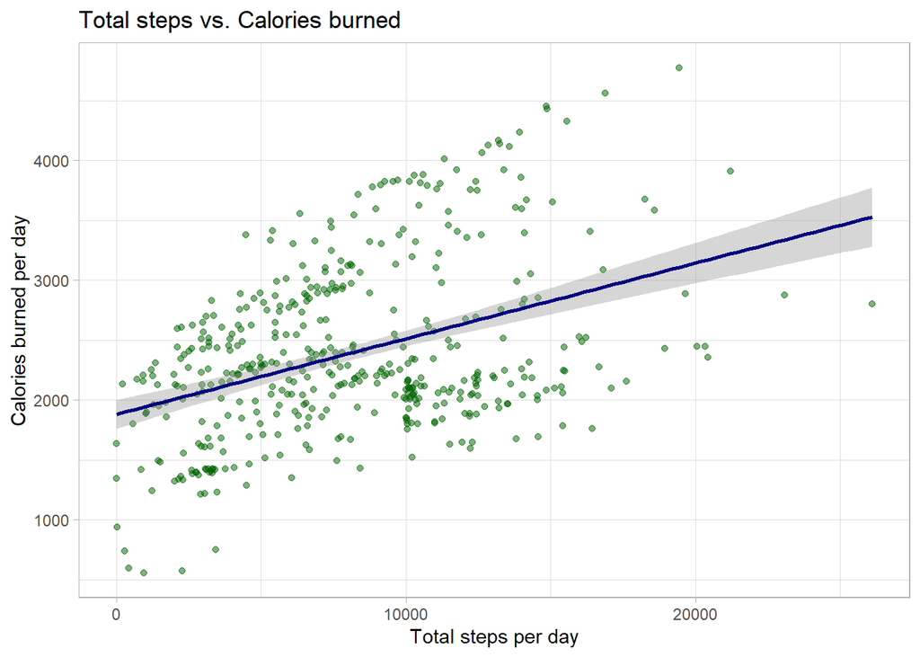

```r
ggplot(data=daily_summary, aes(x=total_steps, y=total_calories)) +
  geom_point(color = "darkgreen", alpha = 0.5) +
  geom_smooth(method = "lm", color = "navy") +
  labs(title = "Total steps vs. Calories burned",
       x = "Total steps per day",
       y = "Calories burned per day") +
  theme_light()
```

```r
ggsave("steps_vs_calories.png")
```

### 5.2. Plot: Total minutes asleep vs. Total daily intensity

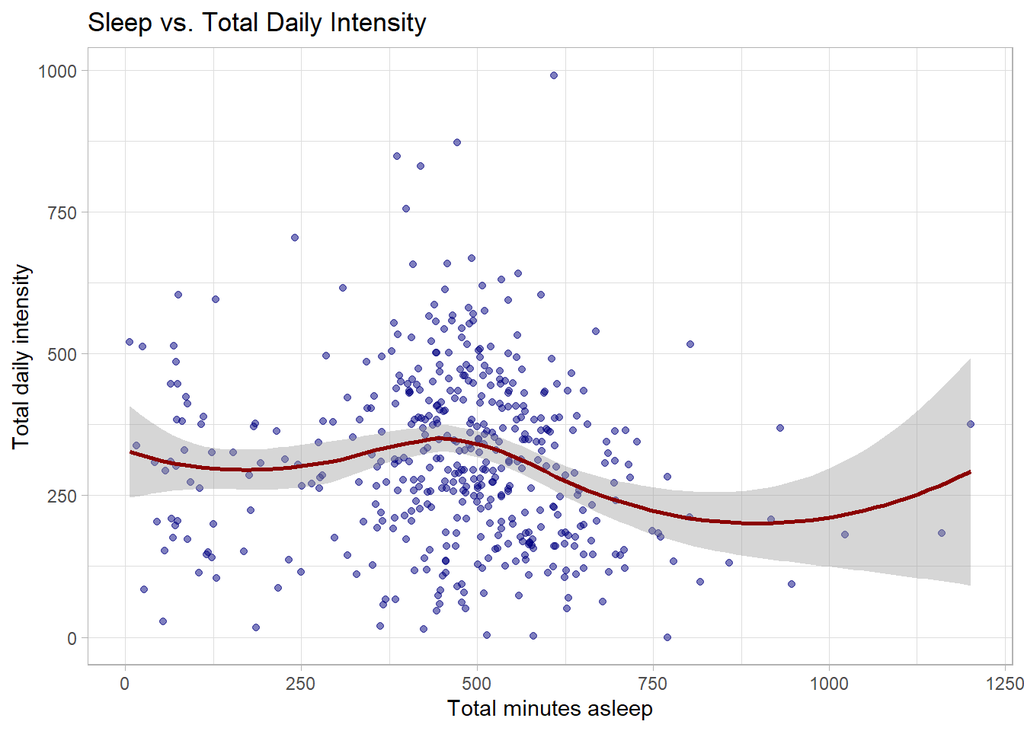

```r
ggplot(data = daily_summary, aes(x=total_minutes_asleep, y=total_intensity)) +
  geom_point(color = "navy", alpha = 0.5) +
  geom_smooth(color = "darkred") +
  labs(title = "Sleep vs. Total Daily Intensity",
       x = "Total minutes asleep",
       y = "Total daily intensity") +
  theme_light()
```

```r
ggsave("sleep_vs_intensity.png")
```

### 5.3. Plot: Average steps by hours

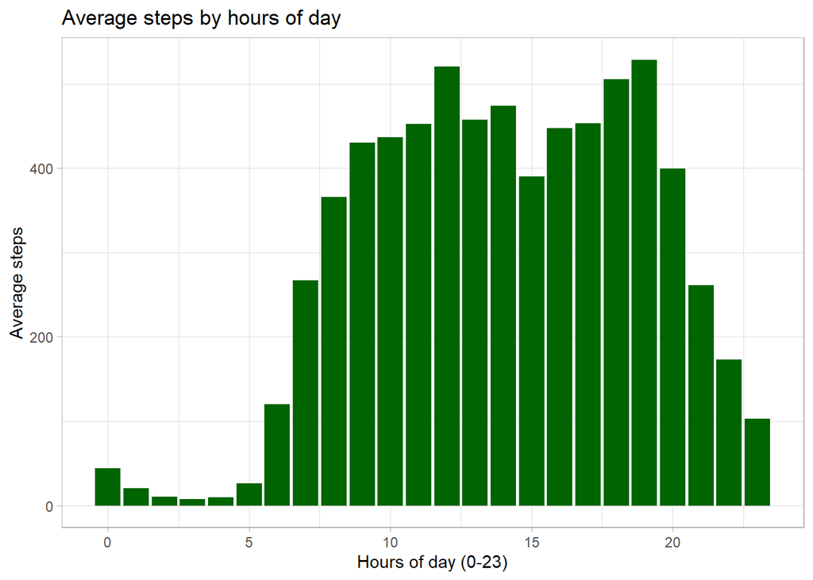

```r
ggplot(data= hourly_avg, aes(x=hour, y=avg_steps)) +
  geom_col(fill="darkgreen")+
  labs(title = "Average steps by hours of day",
       x= "Hours of day (0-23)",
       y= "Average steps") +
  theme_light()
```

```r
ggsave("hourly_activity.png")
```